# act_report

## Report: act_report

- Create a **250-word-minimum written report** called "act_report.pdf" or "act_report.html" that communicates the insights and displays the visualization(s) produced from your wrangled data. This is to be framed as an external document, like a blog post or magazine article, for example.

### Report : A Review of the WeRateDogs Twitter Archive

#### Introduction

The WeRateDogs Twitter archive contains a collection of tweets gathered over time from the @dogrates twitter handle. @dogrates is a twitter user who posts varying information about dogs including ratings. The archive contains the user's posts as well as reactions from viewers such as retweets, favorites(likes), images, urls etc.

To get enough data for this review we had to combine data from 3 different sources starting with the existing archive of tweets then we downloaded additional data from the web on the which contains the image urls and dog preditions. Finally we extracted additional data from the twitter api which contained data on the retweet and favorites counts on each tweet.

#### Objectives

The objectives of this review is to get insights on the content posted by the @dogrates twitter handle such as the dog ratings as well as the reaction of his audience to the content provided such as favorites and retweets. The review will also try to find out if there were specific factors that influenced the audience reactions or the dog ratings.

#### Insights

The available data was processed using a process called data wrangling following which further analysis was conducted on the processed data and the follwoing insights extracted.

1. The Golden retriever is the most popular dog breed tweeted about.
2. Tweets about the Golden Retriever breed received the most retweets and favorites count.
3. The top 5 rated dog breeds are (1. Golden retriever, 2. Labrador retriever, 3. Pembroke, 4. Chihuahua and 5. Pug).
4. The tweet_id influences the number of favorites the tweet receives on twitter.
5. The favorite count has a positive effect on the retweet count. This implies that most tweets that were favorited were also retweeted.

### Dog breed ratings

**The Golden retriever had the highest rating of all the dog breeds and is also the most popular dog breed.**

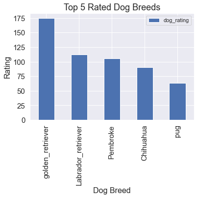

### Impact of the tweet ID on the favorites count.

**The number of favorites (likes) a tweet received was dependent on the ID of that particular tweet.**

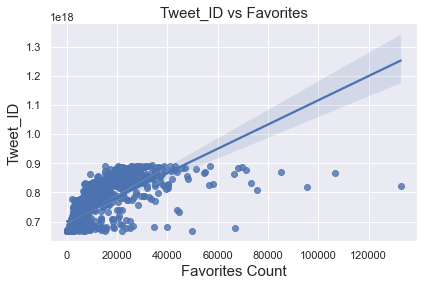

### Impact of favorites count on the retweet count

**Most tweets that were favorited were also retweeted.**

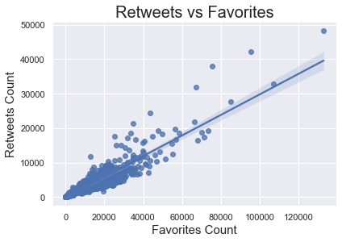

### Conclusion

From the analysis we could see that the Golden retriever dog breed received the highest number of retweets and was also the top rated breed.  
Further analysis revealed that the number of likes/favorites receivd by tweets was linked to the specific tweet ID. Also, Tweets that received a lot of favorites were also retweeted more.

From the insights gotten from the analysis of the data, it can be concluded that tweets relating to the Golden retriever dog breed and any of the other top 5 dog breeds is very likely to receive a lot of favorites and retweets as well as high ratings.  
This indicates that the Golden retriever dog breed is well loved by people.